# Main analyses for ‘Sexual selection for low male voice pitch among Amazonian forager-horticulturists’

Kevin A. Rosenfield

October 17, 2018

This R Markdown file comprehensively documents the steps taken in data treatment and analysis for Rosenfield et al. 2018 “Sexual selection for low male voice pitch among Amazonian forager-horticulturists”

```r
library(lmerTest); library(tidyverse); library(ggplot2); library(ggsignif); library(FSA); library(lme4); library(FactoMineR); library(psych); library(GPArotation); library(lattice); library(MASS); library(gridExtra); library(vcd); library(qpcR);library(QuantPsyc)
```

## Study 1

#### Read in and preview study 1 data; change some factor variables to numeric, separate into two data frames by subjcet sex

```r
Tsimane_study1 <- read.csv("Rosenfieldetal_Study1.csv")

cols.num <- c(5:12)

Tsimane_study1[cols.num] <- sapply(sapply(Tsimane_study1[cols.num],as.character),as.numeric); rm(cols.num)

Tsimane_study1.vert <- Tsimane_study1 %>%
  tidyr::gather(key = condition, value = num_chosen, -ID, -sex, -age, -village) %>%
  tidyr::separate(condition, into = c("char", "manip"), sep="_")

Tsimane_study1_women <- Tsimane_study1.vert %>%
  filter (is.na(num_chosen) == F) %>%
  filter (sex == 0) %>%
  dplyr::select (ID, char, manip, num_chosen)

Tsimane_study1_men <- Tsimane_study1.vert %>%
  filter (is.na(num_chosen) == F) %>%
  filter (sex == 1) %>%
  dplyr::select (ID, char, manip, num_chosen)
```

Preview male and female subjects’ dataframes

```
##    ID char manip num_chosen
## 1   5  pre   fem          4
## 2  66  pre   fem          4
## 3  69  pre   fem          4
## 4 152  pre   fem          4
## 5 105  pre   fem          3
## 6 172  pre   fem          3
```

```
##   ID char manip num_chosen
## 1 11  att   fem          1
## 2 22  att   fem          4
## 3 76  att   fem          4
## 4 73  att   fem          3
## 5 63  att   fem          1
## 6 74  att   fem          1
```

###### char (characteristic rated): pre = prestige; dom = dominance; att = body attractiveness; mar = marraige

###### manip (type of manipulation) mas = masculinized; fem = feminized

###### num_chosen: number of more masculine stimuli (out of 4)

repeated measures ANOVAs testing whether female subjects’ responses differed based on characteristic rated or manipulation type

```r
anova(lmer(num_chosen ~ char*manip + (1|ID), data=Tsimane_study1_women))
```

```
## Type III Analysis of Variance Table with Satterthwaite's method
##             Sum Sq Mean Sq NumDF DenDF F value Pr(>F)
## char       0.05769 0.05769     1   114  0.0464 0.8298
## manip      0.31410 0.31410     1   114  0.2529 0.6160
## char:manip 0.77564 0.77564     1   114  0.6244 0.4310
```

###### no differences based on characteristic, manipulation, or their interaction

repeated measures ANOVAs testing whether male subjects’ responses differed based on characteristic rated or manipulation type

```r
anova(lmer(num_chosen ~ char*manip + (1|ID), data=Tsimane_study1_men))
```

```
## Type III Analysis of Variance Table with Satterthwaite's method
##             Sum Sq Mean Sq NumDF DenDF F value    Pr(>F)
## char       16.2000 16.2000     1   132 13.6329 0.0003242 ***
## manip       0.0222  0.0222     1   132  0.0187 0.8914359
## char:manip  1.4222  1.4222     1   132  1.1969 0.2759436
## ---
## Signif. codes:  0 '***' 0.001 '**' 0.01 '*' 0.05 '.' 0.1 ' ' 1
```

###### men’s responses do not differ depending on type of manipulation but DO differ whether they are rating dominance or prestige

Graph men’s and women’s number of masculiune stimuli chosen under 4 conditions after some data wrangling

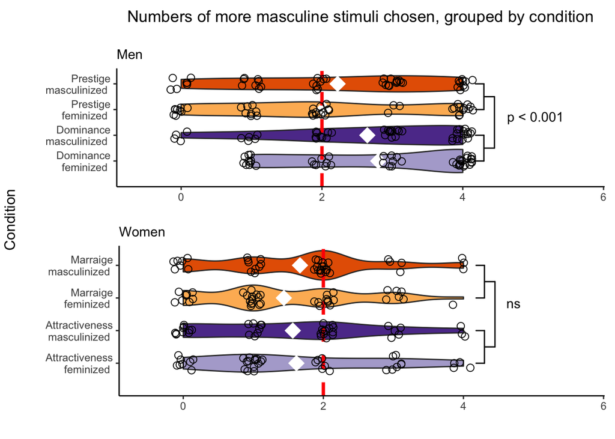

```r
Tsimane_study1_men_plot.data <- Tsimane_study1 %>%
  tidyr::gather(key = condition, value = num_chosen, -ID, -sex, -age, -village) %>%
  filter (sex == 1) %>%
  filter (is.na(num_chosen) == F) %>%
  dplyr::select (ID, condition, num_chosen)

Tsimane_study1_women_plot.data <- Tsimane_study1 %>%
  tidyr::gather(key = condition, value = num_chosen, -ID, -sex, -age, -village) %>%
  filter (sex == 0) %>%
  filter (is.na(num_chosen) == F) %>%
  dplyr::select (ID, condition, num_chosen)

men_conditions <- ggplot(Tsimane_study1_men_plot.data, aes(condition, num_chosen)) + coord_flip() +
  theme(axis.title.y = element_text(hjust = 5)) + ylim(-0.6, 5.7) +
  labs(title = "Numbers of more masculine stimuli chosen, grouped by condition\n",
       subtitle = "Men", x="", y="") +
  scale_x_discrete(breaks=c("dom_fem", "dom_mas", "pre_fem", "pre_mas"),
                   labels=c("Dominance\nfeminized ", "Dominance\nmasculinized ",
                            "Prestige\nfeminized ", "Prestige\nmasculinized ")) +
  geom_violin(aes(fill = condition)) + stat_summary(fun.y=mean, geom="point", shape=18, size=6, color="white") +
  geom_line(data = data.frame(x = c(0,4.5), y = c(2,2)),
            aes(x = x, y = y), colour = "red", linetype="dashed", size = 1.3) +
  geom_jitter(height = 0.15, width = .25, color = 'black', shape = 1, size = 2.5) +
  scale_fill_manual(values = c("#B2ABD2", "#5E3C99", "#FDB863", "#E66101")) + theme_classic() +
  theme(plot.title = element_text(hjust = 0.5), plot.margin =
                            margin(0.3, 0.3, 0, 0.3, "cm"), legend.position="none")  +
  geom_signif(y_position=c(4.45), xmin=c(1.5), xmax=c(3.5),
              annotation=c("p < 0.001"), vjust = 2.7, hjust = -0.4, tip_length = 0.035) +
  geom_signif(y_position=c(4.3, 4.3), xmin=c(1, 3), xmax=c(2, 4),
              annotation=c("", ""), tip_length = 0.03)


women_conditions <- ggplot(Tsimane_study1_women_plot.data, aes(condition, num_chosen)) + coord_flip() +
  theme(axis.title.y = element_text(hjust = 5)) + ylim(-0.6, 5.7) + labs(subtitle = "Women", x="", y="") +
  scale_x_discrete(breaks=c("att_fem", "att_mas", "mar_fem", "mar_mas"),
                   labels=c("Attractiveness\nfeminized ", "Attractiveness\nmasculinized ",
                            "Marraige\nfeminized ", "Marraige\nmasculinized ")) +
  geom_violin(aes(fill = condition)) + stat_summary(fun.y=mean, geom="point", shape=18, size=6, color="white") +
  geom_line(data = data.frame(x = c(0,4.5), y = c(2,2)),
            aes(x = x, y = y), colour = "red", linetype="dashed", size = 1.3) +
  geom_jitter(height = 0.15, width = .25, color = 'black', shape = 1, size = 2.5) +
  scale_fill_manual(values = c("#B2ABD2", "#5E3C99", "#FDB863", "#E66101")) +
  theme_classic() + theme(plot.margin = margin(0.2, 0.3, 0.3, 0.3, "cm"), legend.position="none") +
  geom_signif(y_position=c(4.45), xmin=c(1.5), xmax=c(3.5),
              annotation=c("ns"), vjust = 2.9, hjust = -1.5, tip_length = 0.035) +
  geom_signif(y_position=c(4.3, 4.3), xmin=c(1, 3), xmax=c(2, 4),
              annotation=c("", ""), tip_length = 0.03)

grid.arrange(men_conditions, women_conditions, nrow=2, left = "Condition")
```

###### horizontal jitter applied to data points for ease of viewing; in reality, the num_chosen variable is discrete

###### large white diamonds represent means; dotted red line indicates line of no preference

### Did subjects choose stimuli manipulated away from mean F0 at a rate that differs from chance?

Men

```r
Tsimane_study1_men_manip <- Tsimane_study1_men %>%
  mutate(manip_chosen =
           case_when(
           manip == "fem" ~ 4 - num_chosen,
           manip == "mas" ~ num_chosen
         )) %>%
  group_by(ID) %>%
  summarize(avg_manip = mean(manip_chosen))
t.test(Tsimane_study1_men_manip$avg_manip, mu=2, paired=FALSE, no.action=na.omit)
```

```
##
##  One Sample t-test
##
## data:  Tsimane_study1_men_manip$avg_manip
## t = 0.19986, df = 44, p-value = 0.8425
## alternative hypothesis: true mean is not equal to 2
## 95 percent confidence interval:
##  1.899070 2.123152
## sample estimates:
## mean of x
##  2.011111
```

###### male subjects’ rates of choosing stimuli manipulated away from the mean did not differ from chance

Women

```r
Tsimane_study1_women_manip <- Tsimane_study1_women %>%
  mutate(manip_chosen =
           case_when(
             manip == "fem" ~ 4 - num_chosen,
             manip == "mas" ~ num_chosen
           )) %>%
  group_by(ID) %>%
  summarize(avg_manip = mean(manip_chosen))
t.test(Tsimane_study1_women_manip$avg_manip, mu=2, paired=FALSE, no.action=na.omit)
```

```
##
##  One Sample t-test
##
## data:  Tsimane_study1_women_manip$avg_manip
## t = 0.62115, df = 38, p-value = 0.5382
## alternative hypothesis: true mean is not equal to 2
## 95 percent confidence interval:
##  1.898630 2.191114
## sample estimates:
## mean of x
##  2.044872
```

###### female subjects’ rates of choosing stimuli manipulated away from the mean did not differ from chance

##### based on the above analyses indicating that women answered similarly in all conditions and that men answer differently in prestige vs. dominance conditions:

##### make data frames for women’s overall mean num_chosen, men’s mean num_chosen for dominance, and men’s mean num_chosen for prestige

```r
Tsimane_study1_women_avg <- Tsimane_study1_women %>%
  group_by (ID) %>%
  summarize(avg_chosen = mean(num_chosen))

Tsimane_study1_men_pre_avg <- Tsimane_study1_men %>%
  filter (is.na(num_chosen) == F) %>%
  filter (char == "pre") %>%
  dplyr::select (ID, char, num_chosen) %>%
  group_by (ID, char) %>%
  summarize(avg_chosen = mean(num_chosen))

Tsimane_study1_men_dom_avg <- Tsimane_study1_men %>%
  filter (is.na(num_chosen) == F) %>%
  filter (char == "dom") %>%
  dplyr::select (ID, char, num_chosen) %>%
  group_by (ID, char) %>%
  summarize(avg_chosen = mean(num_chosen))
```

#### 1-sample t-tests: Does number of masculine stimuli selected differ from chance?

women (all conditions combined)

```r
t.test(Tsimane_study1_women_avg$avg_chosen, mu = 2, paired=FALSE, no.action=na.omit)
```

```
##
##  One Sample t-test
##
## data:  Tsimane_study1_women_avg$avg_chosen
## t = -3.9114, df = 38, p-value = 0.000367
## alternative hypothesis: true mean is not equal to 2
## 95 percent confidence interval:
##  1.348225 1.792801
## sample estimates:
## mean of x
##  1.570513
```

###### women chose significantly fewer masculine stimuli than would be expected by chance

men-prestige

```r
t.test(Tsimane_study1_men_pre_avg$avg_chosen, mu = 2, paired=FALSE, no.action=na.omit)
```

```
##
##  One Sample t-test
##
## data:  Tsimane_study1_men_pre_avg$avg_chosen
## t = 0.62766, df = 44, p-value = 0.5335
## alternative hypothesis: true mean is not equal to 2
## 95 percent confidence interval:
##  1.729779 2.514666
## sample estimates:
## mean of x
##  2.122222
```

###### men did not choose a number of masculine stimuli that differs from chance in “prestige” conditions

men-dominance

```r
t.test(Tsimane_study1_men_dom_avg$avg_chosen, mu = 2, paired=FALSE, no.action=na.omit)
```

```
##
##  One Sample t-test
##
## data:  Tsimane_study1_men_dom_avg$avg_chosen
## t = 4.3421, df = 44, p-value = 8.166e-05
## alternative hypothesis: true mean is not equal to 2
## 95 percent confidence interval:
##  2.387007 3.057438
## sample estimates:
## mean of x
##  2.722222
```

###### men chose significantly more masculine stimuli than would be expected by chance in dominance conditions

Cohen’s d (effect size) for perceptions of dominance of masculine vs feminine stimuli

```r
(2-mean(Tsimane_study1_men_dom_avg$avg_chosen)) / sd(Tsimane_study1_men_dom_avg$avg_chosen)
```

```
## [1] -0.6472842
```

Graph women’s overall average number of masculiune stimuli chosen and men’s averages for prestige and dominance separately

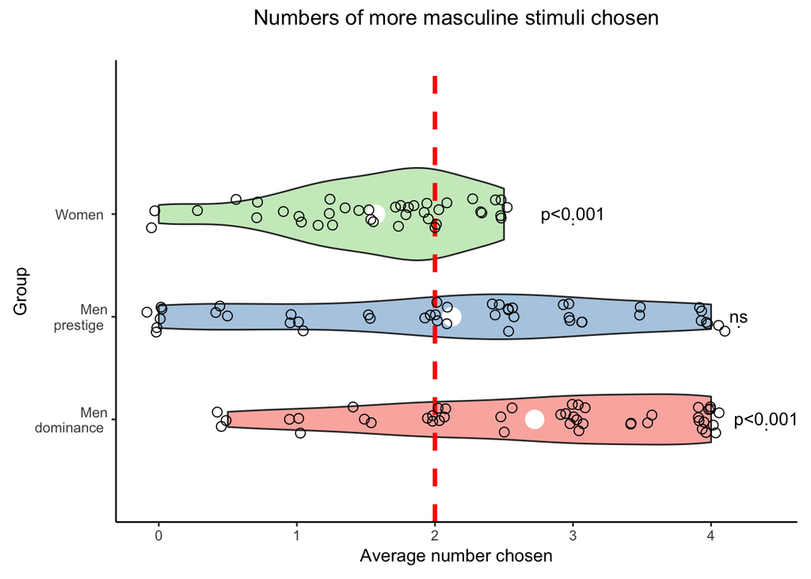

```r
Tsimane_study1_women_avg_dummy <- rbind(Tsimane_study1_women_avg[,2], NA, NA, NA, NA, NA, NA)

figure_2.data <- cbind(c(1:45), Tsimane_study1_women_avg_dummy[,1], Tsimane_study1_men_dom_avg[,3],
                       Tsimane_study1_men_pre_avg[,3])

colnames(figure_2.data) <-  c("ID", "women", "men_dom", "men_pre")
figure_2.data$ID <- as.factor(figure_2.data$ID)

figure_2.data.vert <- figure_2.data %>%
  tidyr::gather(key = group, value = avg_chosen, -ID)


ggplot(figure_2.data.vert, aes(group, avg_chosen)) + coord_flip() + theme(axis.title.y = element_text(hjust = 5)) +
  labs( title = "Numbers of more masculine stimuli chosen\n", x="Group", y="Average number chosen") +
  scale_x_discrete(breaks=c("women", "men_dom", "men_pre"),
                   labels=c("Women ", "Men\ndominance ", "Men\nprestige ")) +
  geom_violin(aes(fill = group)) + stat_summary(fun.y = mean, geom="point", color = "white", size = 5) +
  geom_line(data = data.frame(x = c(0,4.5), y = c(2,2)),
            aes(x = x, y = y), colour = "red", linetype="dashed", size = 1.3) +
  geom_jitter(height = 0.1, width = .15, color = 'black', shape = 1, size = 2.5) +
  scale_fill_brewer(palette="Pastel1") + theme_classic() +
  theme(plot.title = element_text(hjust = 0.5), plot.margin = margin(0.2, 0.3, 0.3, 0.3, "cm"), legend.position="none") +
  geom_signif(y_position=c(4.4, 4.2, 3), xmin=c(0.9, 1.9, 2.9), xmax=c(0.9, 1.9, 2.9),
              annotation=c("p<0.001", "ns", "p<0.001"), tip_length = 0)
```

###### horizontal jitter applied to data points for ease of viewing; in reality, the num_chosen variable is discrete

###### large white dots represent means; dotted red line indicates no preference

## Study 2

Read in study 2 data; change some numeric variables to factors; exclude men who have never married

```r
Tsimane_study2 <- read.csv("Rosenfieldetal_Study2.csv")
Tsimane_study2$ID <- as.factor(Tsimane_study2$ID)
Tsimane_study2$village <- as.factor(Tsimane_study2$village)
Tsimane_study2$men_outlier <- rep(0,68)
Tsimane_study2$wife_outlier <- rep(0,68)
Tsimane_study2_outlierm <- Tsimane_study2 %>%
  filter (Tsimane_study2$ID == 164) %>%
  mutate(men_outlier=replace(men_outlier, , 1))
Tsimane_study2_outlierw <- Tsimane_study2 %>%
  filter (Tsimane_study2$ID == 10) %>%
  mutate(wife_outlier=replace(wife_outlier, , 1))
Tsimane_study2 <- rbind(Tsimane_study2[ which(Tsimane_study2$ID != 10 & Tsimane_study2$ID != 164), ], Tsimane_study2_outlierm, Tsimane_study2_outlierw)
Tsimane_study2$men_outlier <- as.factor(Tsimane_study2$men_outlier)
Tsimane_study2$wife_outlier <- as.factor(Tsimane_study2$wife_outlier)
Tsimane_study2 <- subset(Tsimane_study2, tot_wives != 0)
```

Control variable PCA carried out in SPSS using the folowing code:

FACTOR /VARIABLES weight height biceps tot_wealth /MISSING LISTWISE /ANALYSIS weight height biceps tot_wealth /PRINT INITIAL EXTRACTION ROTATION /CRITERIA MINEIGEN(1) ITERATE(25) /EXTRACTION PC /CRITERIA ITERATE(25) DELTA(0) /ROTATION OBLIMIN /SAVE REG(ALL) /METHOD=CORRELATION.

Factors 1 & 2 extracted as ‘Size’ and Wealth’ scores

```r
  cor.test(Tsimane_study2$Size, Tsimane_study2$Wealth)
```

```
##
##  Pearson's product-moment correlation
##
## data:  Tsimane_study2$Size and Tsimane_study2$Wealth
## t = 0.25041, df = 60, p-value = 0.8031
## alternative hypothesis: true correlation is not equal to 0
## 95 percent confidence interval:
##  -0.2192261  0.2798213
## sample estimates:
##        cor
## 0.03231135
```

```r
  cor.test(Tsimane_study2$biceps, Tsimane_study2$height)
```

```
##
##  Pearson's product-moment correlation
##
## data:  Tsimane_study2$biceps and Tsimane_study2$height
## t = 2.0849, df = 60, p-value = 0.04134
## alternative hypothesis: true correlation is not equal to 0
## 95 percent confidence interval:
##  0.01084903 0.47861069
## sample estimates:
##       cor
## 0.2599129
```

```r
  cor.test(Tsimane_study2$biceps, Tsimane_study2$weight)
```

```
##
##  Pearson's product-moment correlation
##
## data:  Tsimane_study2$biceps and Tsimane_study2$weight
## t = 7.9957, df = 60, p-value = 4.984e-11
## alternative hypothesis: true correlation is not equal to 0
## 95 percent confidence interval:
##  0.5708761 0.8207636
## sample estimates:
##       cor
## 0.7182337
```

```r
  cor.test(Tsimane_study2$weight, Tsimane_study2$height)
```

```
##
##  Pearson's product-moment correlation
##
## data:  Tsimane_study2$weight and Tsimane_study2$height
## t = 4.1417, df = 60, p-value = 0.0001096
## alternative hypothesis: true correlation is not equal to 0
## 95 percent confidence interval:
##  0.2513510 0.6452899
## sample estimates:
##       cor
## 0.4715176
```

###### the PCs are not correlated

Men who had never married were excluded FOLLOWING principal components analysis, as unmarried men still contributed control variable data

```r
Tsimane_study2 <- subset(Tsimane_study2, tot_wives != 0)
```

Log-transform men’s age at first reproduction

```r
Tsimane_study2$log_age_1st_reprod <- log(Tsimane_study2$age_1st_reprod)
```

Log-transform wives’ number of children, then average if two wives

```r
Tsimane_study2$log_w1totalchildren <- log(Tsimane_study2$w1totalchildren + 1)
Tsimane_study2$log_w2totalchildren <- log(Tsimane_study2$w2totalchildren + 1)
Tsimane_study2$mean_log_w_totalchildren <- rowMeans(Tsimane_study2[c('log_w1totalchildren', 'log_w2totalchildren')], na.rm=TRUE)
Tsimane_study2$mean_w_totalchildren <- rowMeans(Tsimane_study2[c('w1totalchildren', 'w2totalchildren')], na.rm=TRUE)
```

Log-transform wives’ age at first reproduction, then average if two wives

```r
Tsimane_study2$log_w1_age_1st_reprod <- log(Tsimane_study2$w1_age_1st_reprod)
Tsimane_study2$log_w2_age_1st_reprod <- log(Tsimane_study2$w2_age_1st_reprod)
Tsimane_study2$mean_log_w_age_1st_reprod <- rowMeans(Tsimane_study2[c('log_w1_age_1st_reprod', 'log_w1_age_1st_reprod')], na.rm=TRUE)
```

Are the totalchildren data normally distributed? Are the residuals of a regression of total children on age and age^2 normally distributed?

```r
shapiro.test(Tsimane_study2$totalchildren)
```

```
##
##  Shapiro-Wilk normality test
##
## data:  Tsimane_study2$totalchildren
## W = 0.87018, p-value = 9.495e-06
```

```r
totalchildren.lm <- residuals(lm(totalchildren ~ poly(age,2), data=Tsimane_study2))
shapiro.test(totalchildren.lm)
```

```
##
##  Shapiro-Wilk normality test
##
## data:  totalchildren.lm
## W = 0.8584, p-value = 4.021e-06
```

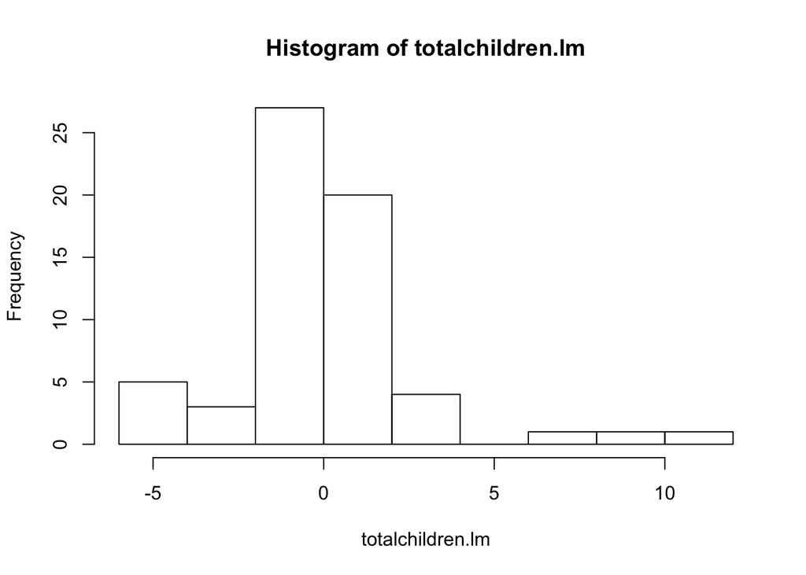

```r
hist(totalchildren.lm)
```

##### the total chilren data do not appear to be normally distributed, nor are the residuals of their regression on age and age^2 normally distributed (histogram is of residuals)

Log-transform men’s number of children (+ 1 to account for childless men); run linear regression and extract residuals; add to dataset

```r
Tsimane_study2$log_kids <- log(Tsimane_study2$totalchildren + 1)
Tsimane_study2$kids_residuals.log.lm <- residuals(lm(log_kids ~ poly(age,2), data=Tsimane_study2, na.action = na.omit))
```

Identifying men’s age-adjusted rs outliers

```r
x <- 3

kids_residuals_mean <- mean(Tsimane_study2$kids_residuals.log.lm, na.rm = TRUE)
kids_residuals_sd <- sd(Tsimane_study2$kids_residuals.log.lm, na.rm = TRUE)
men_outliers <- as.matrix((rbind(
  subset(Tsimane_study2, kids_residuals.log.lm <
                            (kids_residuals_mean - (x * kids_residuals_sd)), select = c(ID, kids_residuals.log.lm)),
  subset(Tsimane_study2, kids_residuals.log.lm >
                            (kids_residuals_mean + (x * kids_residuals_sd)), select = c(ID, kids_residuals.log.lm)))))
men_outliers <- as.data.frame(men_outliers); colnames(men_outliers) <- c("Outliers", "RS")
print(men_outliers)
```

```
##    Outliers        RS
## 17      164 -1.693658
```

###### x = the number of SDs above or below the mean to constitute an outlier

###### one subjects’ age-adjusted RS is more than three SDs below the mean, an analysis excluding this subject can be found in ‘Robustness Analyses’

Create age-adjusted RS variable for wives; second wives’ number of children are in a separate column; create dataset combining first and second wives’ numbers of children

```r
with_1_wife <- subset(Tsimane_study2, w1age > 0, select = c(ID, w1age, w1totalchildren))
with_2_wife <- subset(Tsimane_study2, w2age > 0, select = c(ID, w2age, w2totalchildren))
colnames(with_1_wife) <- c("ID", "age", "totalchildren")
colnames(with_2_wife) <- c("ID", "age", "totalchildren")
all_wives <- rbind(with_1_wife, with_2_wife)
```

Run linear regresson on wives log-transformed RS to obtain wives’ age-adjusted reproductive success; add back into main dataset

```r
all_wives$log_wives_kids <- log(all_wives$totalchildren + 1)
all_wives<- cbind(all_wives, residuals(lm(log_wives_kids ~ poly(age,2), data = all_wives)))
all_wives$wives_residuals.log.lm <-  all_wives[,5]; all_wives <- all_wives[,-5]
wives_residuals.log <- aggregate(log_wives_kids ~ ID, all_wives, mean, all.x = TRUE)
wives_residuals.log.lm <- aggregate(wives_residuals.log.lm ~ ID, all_wives, mean, all.x = TRUE)
Tsimane_study2 <- merge(Tsimane_study2, by="ID", wives_residuals.log.lm, all.x = TRUE)
Tsimane_study2 <- merge(Tsimane_study2, by="ID", wives_residuals.log, all.x = TRUE)
rm(wives_residuals.log.lm)
```

Identifying wives’ age-adjusted rs outliers

```r
y <- 3
wives_residuals_mean <- mean(all_wives$wives_residuals.log.lm, na.rm = TRUE)
wives_residuals_sd <- sd(all_wives$wives_residuals.log.lm, na.rm = TRUE)
wives_outliers <- rbind(
    subset(all_wives, wives_residuals.log.lm <
             (wives_residuals_mean - (y * wives_residuals_sd)), select = c(ID, wives_residuals.log.lm)),
    subset(all_wives, wives_residuals.log.lm >
             (wives_residuals_mean + (y * wives_residuals_sd)), select = c(ID, wives_residuals.log.lm)))
wives_outliers <- as.data.frame(wives_outliers); colnames(wives_outliers) <- c("Outliers", "RS")
print(wives_outliers)
```

```
##     Outliers         RS
## 23        46 -0.9493966
## 110       10 -1.2021723
```

###### y = the number of SDs above or below the mean to constitute an outlier

###### the outlier column refers to the ID number of the husband

###### two wives’ age-adjusted RS is more than three SDs below the mean; an analysis excluding these wives can be found in ‘Robustness Analyses’

Preview of study data after transformations

```r
head(Tsimane_study2)
```

```
##   ID age village weight height biceps tot_wealth curr_Wives tot_wives totalchildren prop_kids_died age_1st_reprod
## 1  4  50       1   67.6  168.7   33.4       3050          1         1             9      0.1111111             23
## 2  5  25       1   77.3  179.0   32.0       4750          1         1             3      0.3333333             19
## 3  8  31       1   62.8  162.3   31.5       1850          1         1             4      0.0000000             23
## 4 10  43       1   70.2  175.4   30.8        750          1         2             2      0.0000000             19
## 5 12  26       1   77.3  172.3   34.9       2825          1         1             3      0.0000000             20
## 6 15  23       1   57.1  164.5   28.1       1300          1         1             2      0.5000000             21
##    meanF0 w1age w1totalchildren w1deadchildrenunder16 w1_prop_kids_died w1_age_1st_reprod w2age w2totalchildren
## 1 135.083    40               9                     1         0.1111111                17    NA              NA
## 2 135.736    21               3                     1         0.3333333                15    NA              NA
## 3 128.170    22               4                     0         0.0000000                16    NA              NA
## 4 114.784    43               2                     0         0.0000000                20    NA              NA
## 5 133.747    23               3                     0         0.0000000                19    NA              NA
## 6 106.068    21               2                     1         0.5000000                19    NA              NA
##   w2deadchildrenunder16 w2_age_1st_reprod       Size     Wealth village_f0 men_outlier wife_outlier log_age_1st_reprod
```

[output cut: 20 more lines]

Are there overall inter-village differences in men’s mean F0, RS, or control variables?

```r
manova1 <- manova(cbind(curr_Wives, tot_wives, prop_kids_died, log_age_1st_reprod, mean_log_w_age_1st_reprod,
                     wives_residuals.log.lm, kids_residuals.log.lm, meanF0, Size, Wealth)~ village, data = Tsimane_study2)

summary(manova1)
```

```
##           Df Pillai approx F num Df den Df Pr(>F)
## village    5 1.1854   1.2431     50    200   0.15
## Residuals 45
```

###### village ID does not predict overal differences in subject-level variables

Are there specific inter-village differences in men’s mean F0, RS, or control variables?

```r
summary.aov(manova1)
```

```
##  Response curr_Wives :
##             Df  Sum Sq  Mean Sq F value Pr(>F)
## village      5 0.42353 0.084706  1.5882 0.1828
## Residuals   45 2.40000 0.053333
##
##  Response tot_wives :
##             Df Sum Sq  Mean Sq F value Pr(>F)
## village      5 0.2618 0.052353  0.2575 0.9338
## Residuals   45 9.1500 0.203333
##
##  Response prop_kids_died :
##             Df  Sum Sq  Mean Sq F value   Pr(>F)
## village      5 0.46628 0.093256  4.1381 0.003543 **
## Residuals   45 1.01412 0.022536
## ---
## Signif. codes:  0 '***' 0.001 '**' 0.01 '*' 0.05 '.' 0.1 ' ' 1
##
##  Response log_age_1st_reprod :
##             Df  Sum Sq  Mean Sq F value Pr(>F)
## village      5 0.09067 0.018134   0.503 0.7724
## Residuals   45 1.62252 0.036056
##
##  Response mean_log_w_age_1st_reprod :
##             Df  Sum Sq  Mean Sq F value Pr(>F)
## village      5 0.14468 0.028936  1.1384 0.3542
## Residuals   45 1.14378 0.025417
##
##  Response wives_residuals.log.lm :
##             Df Sum Sq  Mean Sq F value Pr(>F)
## village      5 0.3348 0.066952  0.8758  0.505
## Residuals   45 3.4402 0.076449
##
##  Response kids_residuals.log.lm :
##             Df Sum Sq  Mean Sq F value Pr(>F)
## village      5 0.1351 0.027025   0.251 0.9371
## Residuals   45 4.8445 0.107655
##
##  Response meanF0 :
##             Df Sum Sq Mean Sq F value   Pr(>F)
## village      5 3393.0  678.60  3.6684 0.007205 **
## Residuals   45 8324.4  184.99
## ---
## Signif. codes:  0 '***' 0.001 '**' 0.01 '*' 0.05 '.' 0.1 ' ' 1
##
##  Response Size :
##             Df Sum Sq Mean Sq F value Pr(>F)
## village      5  6.870  1.3739  1.3022   0.28
## Residuals   45 47.479  1.0551
##
##  Response Wealth :
##             Df Sum Sq Mean Sq F value Pr(>F)
## village      5  7.976 1.59512  1.5973 0.1803
## Residuals   45 44.938 0.99862
##
## 11 observations deleted due to missingness
```

###### propoirtion of offspring that died before age 16 differs significantly between villages

###### fundamental frequency differs significantly between villages

Zero-order correlation table including men’s mean F0 and all dependent and control variables

```r
attach(Tsimane_study2)
cor_data <- as.data.frame(qpcR:::cbind.na(meanF0, curr_Wives, tot_wives, prop_kids_died, age, Wealth, Size, mean_log_w_age_1st_reprod, log_age_1st_reprod, log_kids, mean_log_w_totalchildren))
F0_cor <- corr.test(cor_data, adjust = "holm")
F0_cor <- round(as.data.frame(cbind(F0_cor$n[2:11,1], F0_cor$ci$lower[1:10], F0_cor$r[2:11,1], F0_cor$ci$upper[1:10], F0_cor$p[2:11,1])), 3)
colnames(F0_cor) <- c("N", "95% lower limit", "Pearson's R", "95% upper limit", "p-Value")
rownames(F0_cor) <- c("Current wives", "Total wives", "Offspring died under age 16 (%)", "Age", "Wealth", "Size", "Log wives' age at first reproduction", "Log age at first reproduction", "Log-transformed RS", "Wives' age-adjusted RS")
print(F0_cor)
```

```
##                                       N 95% lower limit Pearson's R 95% upper limit p-Value
## Current wives                        59          -0.209       0.050           0.302   0.709
## Total wives                          59          -0.435      -0.201           0.058   0.127
## Offspring died under age 16 (%)      57          -0.245       0.017           0.276   0.901
## Age                                  59          -0.433      -0.199           0.060   0.130
## Wealth                               59          -0.424      -0.188           0.071   0.153
## Size                                 59          -0.362      -0.117           0.143   0.377
## Log wives' age at first reproduction 52          -0.398      -0.140           0.138   0.321
## Log age at first reproduction        55          -0.359      -0.104           0.166   0.449
## Log-transformed RS                   59          -0.510      -0.292          -0.039   0.025
## Wives' age-adjusted RS               53          -0.537      -0.312          -0.045   0.023
```

###### F0 is significantly, and negatively, correlated with men’s and wives’ log-transformed reproductive success, but no other variable

#### Linear models testing whether men’s mean fundamental frequency predicts aspects of reproductive success, controlling for size, wealth, age, and age^2

```r
tsimane2_currwives_lm <- lm(curr_Wives~ meanF0 + Size + Wealth + poly(age,2), data=Tsimane_study2, na.action = na.omit)
tsimane2_totwives_lm <- lm(tot_wives~ meanF0 + Size + Wealth + poly(age,2), data=Tsimane_study2, na.action = na.omit)
tsimane2_propdied_lm <- lm(prop_kids_died~ meanF0 + Size + Wealth + poly(age,2), data=Tsimane_study2, na.action = na.omit)
tsimane2_age1st_lm <- lm(log_age_1st_reprod~ meanF0 + Size + Wealth + poly(age,2), data=Tsimane_study2, na.action = na.omit)
tsimane2_w_age1st_lm <- lm(mean_log_w_age_1st_reprod~ meanF0 + Size + Wealth + poly(age,2), data=Tsimane_study2, na.action = na.omit)
tsimane2_logkids_lm <- lm(log_kids~ meanF0 + Size + Wealth + poly(age,2), data=Tsimane_study2, na.action = na.omit)
tsimane2_w_RS_lm <- lm(wives_residuals.log.lm~ meanF0 + Size + Wealth + poly(age,2), data=Tsimane_study2, na.action = na.omit)
Tsimane_study2.stand.betas <- as.data.frame(c(lm.beta(tsimane2_currwives_lm)[1],lm.beta(tsimane2_totwives_lm)[1], lm.beta(tsimane2_propdied_lm)[1],lm.beta(tsimane2_age1st_lm)[1],lm.beta(tsimane2_w_age1st_lm)[1],lm.beta(tsimane2_logkids_lm)[1],lm.beta(tsimane2_w_RS_lm)[1]))
colnames(Tsimane_study2.stand.betas) <- "beta"
```

```r
model_table <- t(round(as.data.frame(cbind(summary(tsimane2_currwives_lm)$coefficients[2,c(3,4)],summary(tsimane2_totwives_lm)$coefficients[2,c(3,4)], summary(tsimane2_propdied_lm)$coefficients[2,c(3,4)], summary(tsimane2_age1st_lm)$coefficients[2,c(3,4)], summary(tsimane2_w_age1st_lm)$coefficients[2,c(3,4)], summary(tsimane2_logkids_lm)$coefficients[2,c(3,4)], summary(tsimane2_w_RS_lm)$coefficients[2,c(3,4)])), 3))

rownames(model_table) <- c("Current wives", "Total wives", "Offspring mortality", "Age at 1st reproduction", "Wives' age at 1st reproduction", "Log number of offspring", "Wives' age-adjusted RS")

colnames(model_table) <- c("t stat", "p-value")

model_table <- cbind(Tsimane_study2.stand.betas, model_table)

print(model_table)
```

```
##                                       beta t stat p-value
## Current wives                   0.02300285  0.172   0.864
## Total wives                    -0.12360451 -0.936   0.354
## Offspring mortality             0.04632980  0.327   0.745
## Age at 1st reproduction        -0.05567016 -0.434   0.666
## Wives' age at 1st reproduction -0.13068002 -0.933   0.356
## Log number of offspring        -0.14060442 -1.672   0.100
## Wives' age-adjusted RS         -0.26982589 -1.898   0.064
```

```r
tsimane2_currwives_vill_lm <- lm(curr_Wives~ meanF0 + Size + Wealth + poly(age,2) + village_f0, data=Tsimane_study2, na.action = na.omit)
tsimane2_totwives_vill_lm <- lm(tot_wives~ meanF0 + Size + Wealth + poly(age,2) + village_f0, data=Tsimane_study2, na.action = na.omit)
tsimane2_propdied_vill_lm <- lm(prop_kids_died~ meanF0 + Size + Wealth + poly(age,2) + village_f0, data=Tsimane_study2, na.action = na.omit)
tsimane2_age1st_vill_lm <- lm(log_age_1st_reprod~ meanF0 + Size + Wealth + poly(age,2) + village_f0, data=Tsimane_study2, na.action = na.omit)
tsimane2_w_age1st_vill_lm <- lm(mean_log_w_age_1st_reprod~ meanF0 + Size + Wealth + poly(age,2) + village_f0, data=Tsimane_study2, na.action = na.omit)
tsimane2_logkids_vill_lm <- lm(log_kids~ meanF0 + Size + Wealth + poly(age,2) + village_f0, data=Tsimane_study2, na.action = na.omit)
tsimane2_w_RS_vill_lm <- lm(wives_residuals.log.lm~ meanF0 + Size + Wealth + poly(age,2) + village_f0, data=Tsimane_study2, na.action = na.omit)
Tsimane_study2.stand.vill.betas <- as.data.frame(c(lm.beta(tsimane2_currwives_vill_lm)[1],lm.beta(tsimane2_totwives_vill_lm)[1], lm.beta(tsimane2_propdied_vill_lm)[1],lm.beta(tsimane2_age1st_vill_lm)[1],lm.beta(tsimane2_w_age1st_vill_lm)[1],lm.beta(tsimane2_logkids_vill_lm)[1],lm.beta(tsimane2_w_RS_vill_lm)[1]))
colnames(Tsimane_study2.stand.vill.betas) <- "beta"
```

```r
model_table_vill <- t(round(as.data.frame(cbind(summary(tsimane2_currwives_vill_lm)$coefficients[2,c(3,4)],summary(tsimane2_totwives_vill_lm)$coefficients[2,c(3,4)], summary(tsimane2_propdied_vill_lm)$coefficients[2,c(3,4)], summary(tsimane2_age1st_vill_lm)$coefficients[2,c(3,4)], summary(tsimane2_w_age1st_vill_lm)$coefficients[2,c(3,4)], summary(tsimane2_logkids_vill_lm)$coefficients[2,c(3,4)], summary(tsimane2_w_RS_vill_lm)$coefficients[2,c(3,4)])), 3))

rownames(model_table_vill) <- c("Current wives", "Total wives", "Offspring mortality", "Age at 1st reproduction", "Wives' age at 1st reproduction", "Log number of offspring", "Wives' age-adjusted RS")

colnames(model_table_vill) <- c("t stat", "p-value")

model_table_vill <- cbind(Tsimane_study2.stand.vill.betas, model_table_vill)

print(model_table_vill)
```

```
##                                        beta t stat p-value
## Current wives                   0.239563808  1.551   0.127
## Total wives                    -0.053814022 -0.335   0.739
## Offspring mortality            -0.168611930 -1.065   0.292
## Age at 1st reproduction         0.006256912  0.044   0.965
## Wives' age at 1st reproduction -0.141817689 -0.807   0.424
## Log number of offspring        -0.019500893 -0.198   0.844
## Wives' age-adjusted RS         -0.212102945 -1.145   0.258
```

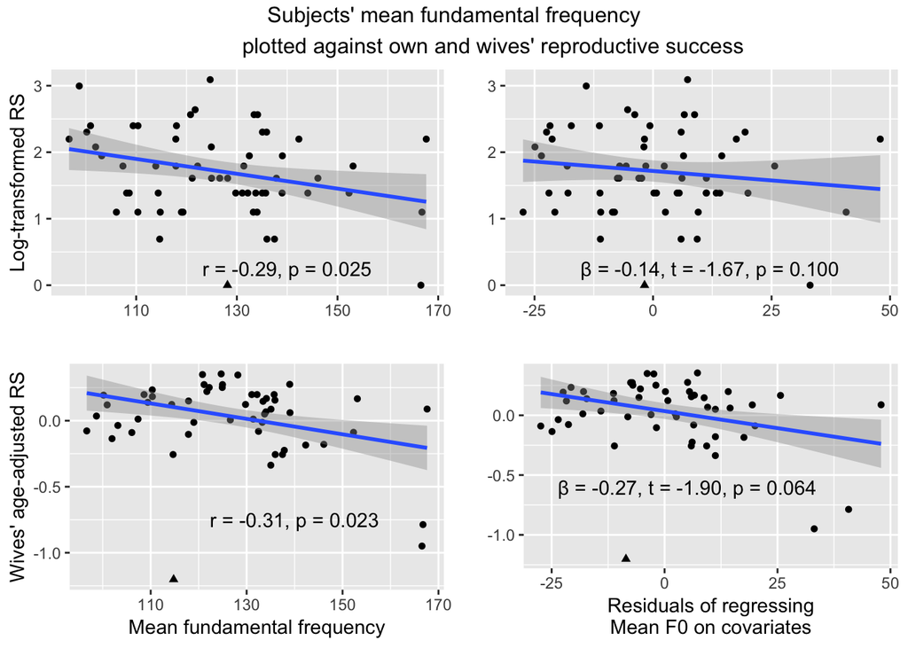

```r
Tsimane_study2_fig <- subset(Tsimane_study2, is.na(meanF0) == FALSE)
Tsimane_study2_fig$tsimane2_meanF0_residuals <- residuals(lm(meanF0~ Size + Wealth + poly(age,2), data=Tsimane_study2_fig, na.action = na.omit))

F0_rs_fig <- ggplot(Tsimane_study2, aes(x=meanF0, y=log_kids, shape = men_outlier, shape = men_outlier)) + geom_point() + geom_smooth(method=lm) +
  annotate(geom="text", x=140, y=0.25, label="r = -0.29, p = 0.025") + labs(x="", y = "Log-transformed RS") + theme(legend.position="none")

F0adj_rs_fig <- ggplot(Tsimane_study2_fig, aes(x=tsimane2_meanF0_residuals, y=log_kids, shape = men_outlier, shape = men_outlier)) + geom_point() +
  geom_smooth(method=lm) + annotate(geom="text", x=12.0, y=0.25, label="β = -0.14, t = -1.67, p = 0.100") + labs(x="", y = "") +
  theme(legend.position="none")

F0_w_rs_fig <- ggplot(Tsimane_study2, aes(x=meanF0, y=wives_residuals.log.lm, shape = wife_outlier, shape = wife_outlier)) + geom_point() + geom_smooth(method=lm) +
  annotate(geom="text", x=140, y=-0.75, label="r = -0.31, p = 0.023") + labs(x="Mean fundamental frequency", y = "Wives' age-adjusted RS") +
  theme(legend.position="none")

F0adj_w_rs_fig <- ggplot(Tsimane_study2_fig, aes(x=tsimane2_meanF0_residuals, y=wives_residuals.log.lm, shape = wife_outlier, shape = wife_outlier)) + geom_point() +
  geom_smooth(method=lm) + annotate(geom="text", x=5.0, y=-0.6, label="β = -0.27, t = -1.90, p = 0.064") +
  labs(x="Residuals of regressing\nMean F0 on covariates", y = "") + theme(legend.position="none")


grid.arrange(F0_rs_fig, F0adj_rs_fig, F0_w_rs_fig, F0adj_w_rs_fig, nrow=2, top="Subjects' mean fundamental frequency
             plotted against own and wives' reproductive success")
```